# Class 13

Investigating cancer genomics datasets

Barry Grant < http://thegrantlab.org/ >  
2022-02-28 (09:57:19 PST on Mon, Feb 28)

# Overview

Cancer is fundamentally a disease of the genome, caused by changes in the DNA, RNA, and proteins of a cell that push cell growth into overdrive. Identifying the genomic alterations that arise in a given cancer can help researchers decode how a particular cancer develops and improve upon the diagnosis and treatment of cancers based on their distinct molecular abnormalities.

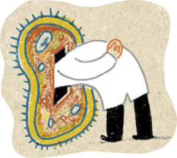

With the ability to sequence whole genomes and exomes, attention has turned to trying to understand the full spectrum of genetic mutations that underlie cancer.

The genomes or exomes of tens of thousands of cancers have now been sequenced. Analyzing this data can yield important new insights into cancer biology. This is important because it is estimated that cancer will strike over 40% of people at some point in their lifetime with frequently devastating effects.

# 1. The NCI Genomic Data Commons

The National Cancer Institute (NCI) in the US has established the [**Genomic Data Commons**](https://gdc.cancer.gov/about-gdc) (or **GDC** for short) for sharing cancer genomics data-sets.

This includes data from a range of large scale projects such as **The Cancer Genome Atlas** (TCGA) and other projects. The TGCA project aims to generate comprehensive, multi-dimensional maps of the key genomic changes in major types and sub-types of cancer. As of writing, TCGA has analyzed matched tumor and normal tissues from over 11,000 patients covering 33 cancer types and sub-types.

You can get a feel for the types of cancer data contained in the NCI-GDC by visiting their new web portal: https://portal.gdc.cancer.gov.

## Exploring the GDC online

Visit the NCI-GDC web portal and enter p53 into the search box.

> **Q1**. How many *Cases* (i.e. patient samples) have been found to have p53 mutations?

> **Q2**. What are the top 6 misssense mutations found in this gene?  
> **HINT:** Scroll down to the ‘TP53 - Protein’ section and mouse over the displayed plot. For example **R175H** is found in 156 cases.

> **Q3**. Which domain of the protein (as annotated by PFAM) do these mutations reside in?

> **Q4**. What are the top 6 *primary sites* (i.e. cancer locations such as Lung, Brain, etc.) with p53 mutations and how many *primary sites* have p53 mutations been found in?  
> **HINT:** Clicking on the number links in the *Cancer Distribution* section will take you to a summary of available data accross *cases*, *genes*, and *mutations* for p53. Looking at the *cases* data will give you a ranked listing of *primary sites*.

Return to the NCI-GDC homepage and using a similar search and explore strategy answer the following questions:

> **Q5**. What is the most frequentely mutated position associated with cancer in the **KRas** protein (i.e. the amino acid with the most mutations)?

> **Q6**. Are KRas mutations common in Pancreatic Adenocarcinoma (i.e. is the Pancreas a common ‘*primary site*’ for KRas mutations?).

> **Q6**. What is the ‘*TGCA project*’ with the most KRas mutations?

> **Q7**. What precent of cases for this ‘*TGCA project*’ have KRas mutations and what precent of cases have p53 mutations?  
> **HINT:** Placing your mouse over the project bar in the **Cancer Distribution** panel will bring up a tooltip with useful summary data.

> **Q8**. How many TGCA Pancreatic Adenocarcinoma *cases* (i.e. patients from the TCGA-PAAD project) have RNA-Seq data available?

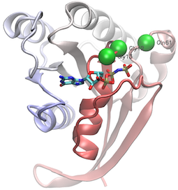

> **Side-Note**: If Barry forgets please remind him to show the top miss-sense mutation sites on the protein structure (and discuss mechanism) as well as demo how to find RNA-Seq FASTQ files and other data such as biopsy images etc.

By now it should be clear that the NCI-GDC is a rich source of both genomic and clinical data for a wide range of cancers. For example, at the time of writing there are 5,306 files associated with Pancreatic Adenocarcinoma and 14,278 for Colon Adenocarcinoma. These include RNA-Seq, WXS (whole exome sequencing), Methylation and Genotyping arrays as well as well as rich metadata associated with each case, file and biospecimen.

# 2. The GenomicDataCommons R package

The [GenomicDataCommons](https://bioconductor.org/packages/release/bioc/html/GenomicDataCommons.html) Bioconductor package provides functions for querying, accessing, and mining the NCI-GDC in R. Using this package allows us to couple large cancer genomics data sets (for example the actual RNA-Seq, WXS or SNP data) directly to the plethora of state-of-the-art bioinformatics methods available in R. This is important because it greatly facilitates both targeted and exploratory analysis of molecular cancer data well beyond that accessible via a web portal.

This section highlights how one can couple the [GenomicDataCommons](https://bioconductor.org/packages/release/bioc/html/GenomicDataCommons.html), [TCGAbiolinks](http://bioconductor.org/packages/release/bioc/html/TCGAbiolinks.html) and [maftools](https://bioconductor.org/packages/release/bioc/html/maftools.html) bioconductor packages to quickly gain insight into public cancer genomics data-sets.

We will first use functions from the `GenomicDataCommons` package to identify and then fetch, using the `TCGAbiolinks` package, somatic variant results from the NCI-GDC and then provide a high-level assessment of those variants using the `maftools` package. The later package works with Mutation Annotation Format or **MAF** format files used by GDC and others to store somatic variants.

The workflow will be:

- Install packages if not already installed
- Load libraries
- Identify and download somatic variants for a representative TCGA dataset, in this case pancreatic adenocarcinoma.
- Use maftools to provide rich summaries of the data.

```r
#source("https://bioconductor.org/biocLite.R")
#biocLite(c("GenomicDataCommons", "TCGAbiolinks", "maftools"))
BiocManager::install( c("GenomicDataCommons", "TCGAbiolinks", "maftools") )
```

Once installed, load the packages, as usual.

```r
library(GenomicDataCommons)
library(TCGAbiolinks)
library(maftools)
```

Now lets check on GDC status:

```r
status()
```

```
## $commit
## [1] "b49b90e1318040f447906940f3dff145809d9ea0"
##
## $data_release
## [1] "Data Release 31.0 - October 29, 2021"
##
## $status
## [1] "OK"
##
## $tag
## [1] "3.0.0"
##
## $version
## [1] 1
```

If this statement results in an error such as `SSL connect error`, then please see the [troubleshooting section here](https://bioconductor.org/packages/release/bioc/vignettes/GenomicDataCommons/inst/doc/overview.html#ssl-connection-errors).

# 3. Querying the GDC from R

We will typically start our interaction with the GDC by searching the resource to find data that we are interested in investigating further. In GDC speak this is called *“Querying GDC metadata”*. Metadata here refers to the extra descriptive information associated with the actual patient data (i.e. ‘cases’) in the GDC.

> **For example**: Our query might be ‘**find how many patients were studied for each major project**’ or ‘**find and download all gene expression quantification data files for all pancreatic cancer patients**’. We will answer both of these questions below.

The are four main sets of metadata that we can query, namely `projects()`, `cases()`, `files()`, and `annotations()`. We will start with `projects()`

```r
projects <- getGDCprojects()
head(projects)
```

|  | id | primary_site | dbgap_accession_number | project_id | disease_type | name | releasable | state | released | tumor |
| --- | --- | --- | --- | --- | --- | --- | --- | --- | --- | --- |
| 1 | TCGA-BRCA |  | NA | TCGA-BRCA |  | Breast Invasive Carcinoma | TRUE | open | TRUE | BRCA |
| 2 | GENIE-MSK |  | NA | GENIE-MSK |  | AACR Project GENIE - Contributed by Memorial Sloan Kettering Cancer Center | FALSE | open | TRUE | MSK |
| 3 | GENIE-VICC |  | NA | GENIE-VICC |  | AACR Project GENIE - Contributed by Vanderbilt-Ingram Cancer Center | FALSE | open | TRUE | VICC |
| 4 | GENIE-UHN |  | NA | GENIE-UHN |  | AACR Project GENIE - Contributed by Princess Margaret Cancer Centre | FALSE | open | TRUE | UHN |
| 5 | CPTAC-2 |  | phs000892 | CPTAC-2 |  | CPTAC-Breast, Colon, Ovary | TRUE | open | TRUE | 2 |
| 6 | CMI-ASC |  | phs001931 | CMI-ASC |  | Count Me In (CMI): The Angiosarcoma (ASC) Project | TRUE | open | TRUE | ASC |

If you use the `View(projects)` function call you can see all the project names (such as Neuroblastoma, Pancreatic Adenocarcinoma, etc.) along with their project IDs (such as TARGET-NBL, TCGA-PAAD, etc.) and associated information.

Moving onto `cases()` we can use an example from the package associated [publication](https://www.biorxiv.org/content/biorxiv/early/2017/04/04/117200.full.pdf) to answer our first from question above (i.e. find the number of cases/patients across different projects within the GDC):

```r
cases_by_project <- cases() %>%
  facet("project.project_id") %>%
  aggregations()
head(cases_by_project)
```

```
## $project.project_id
##    doc_count                   key
## 1      18004                 FM-AD
## 2      16824             GENIE-MSK
## 3      14232            GENIE-DFCI
## 4       3857             GENIE-MDA
## 5       3320             GENIE-JHU
## 6       2632             GENIE-UHN
## 7       2145            TARGET-AML
## 8       2052            GENIE-VICC
## 9       1587         TARGET-ALL-P2
## 10      1132            TARGET-NBL
## 11      1098             TCGA-BRCA
## 12      1038            GENIE-GRCC
## 13       995         MMRF-COMMPASS
```

[output cut: 57 more lines]

Note that the **facet()** and **aggregations()** functions here are from the `GenomicDataCommons` package and act to group all cases by the project id and then count them up.

If you use the **View()** function on our new `cases_by_project` object you will find that the data we are after is accessible via `cases_by_project$project.project_id`.

> **Q9**. Write the R code to make a barplot of the cases per project. Lets plot this data with a log scale for the y axis (`log="y"`), rotated axis labels (`las=2`) and color the bar coresponding to the TCGA-PAAD project.

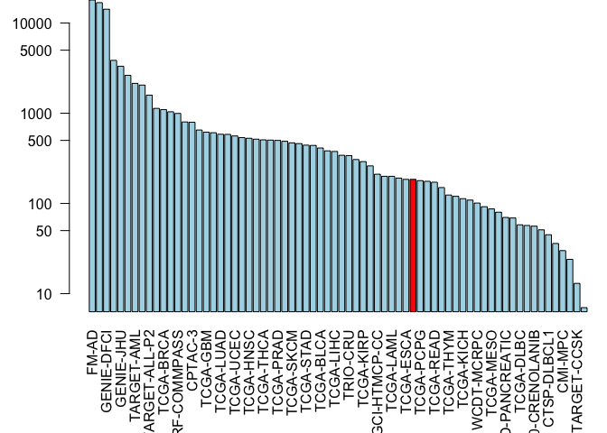

```r
x <- cases_by_project$project.project_id

# Make a custom color vector for our plot
colvec <- rep("lightblue", nrow(x))
colvec[___] <- "red"

# Plot with 'log' for y axis and rotate labels with 'las'
#par(___)
barplot(___, names.arg=___, log="y", col=colvec, las=2)
```

Lets explore some other functions from the related `TCGAbiolinks` package.

We can use the **getSampleFilesSummary()** function to determine for a given project how many cases and what type of data we have available for each case:

```r
samp <- getSampleFilesSummary("TCGA-PAAD")
```

```
## Accessing information for project: TCGA-PAAD
```

```r
head(samp)
```

|  | .id | Biospecimen_Biospecimen Supplement | Biospecimen_Slide Image_Diagnostic Slide | Biospecimen_Slide Image_Tissue Slide | Clinical_Clinical Supplement | Copy Number Variation_Allele-specific Copy Number Segment_Genotyping Array_Affymetrix SNP 6.0 | Copy Number Variation_Copy Number Segment_Genotyping Array_Affymetrix SNP 6.0 | Copy Number Variation_Gene Level Copy Number Scores_Genotyping Array_Affymetrix SNP 6.0 | Copy Number Variation_Gene Level Copy Number_Genotyping Array_Affymetrix SNP 6.0 | Copy Number Variation_Masked Copy Number Segment_Genotyping Array_Affymetrix SNP 6.0 | DNA Methylation_Methylation Beta Value_Methylation Array_Illumina Human Methylation 450 | Proteome Profiling_Protein Expression Quantification_Reverse Phase Protein Array_RPPA | Sequencing Reads_Aligned Reads_miRNA-Seq_Illumina | Sequencing Reads_Aligned Reads_RNA-Seq_Illumina | Sequencing Reads_Aligned Reads_WXS_Illumina | Simple Nucleotide Variation_Aggregated Somatic Mutation_WXS | Simple Nucleotide Variation_Annotated Somatic Mutation_WXS | Simple Nucleotide Variation_Masked Somatic Mutation_WXS | Simple Nucleotide Variation_Raw Simple Somatic Mutation_WXS | Transcriptome Profiling_Gene Expression Quantification_RNA-Seq | Transcriptome Profiling_Isoform Expression Quantification_miRNA-Seq | Transcriptome Profiling_miRNA Expression Quantification_miRNA-Seq | project |
| --- | --- | --- | --- | --- | --- | --- | --- | --- | --- | --- | --- | --- | --- | --- | --- | --- | --- | --- | --- | --- | --- | --- | --- |
| 1 | TCGA-2J-AAB1 | 14 | 1 | 1 | 8 | 1 | 2 | 1 | 1 | 2 | 1 | 0 | 1 | 1 | 2 | 4 | 4 | 4 | 4 | 3 | 1 | 1 | TCGA-PAAD |
| 2 | TCGA-2J-AAB4 | 14 | 1 | 1 | 8 | 1 | 2 | 1 | 1 | 2 | 1 | 1 | 1 | 1 | 2 | 4 | 4 | 4 | 4 | 3 | 1 | 1 | TCGA-PAAD |
| 3 | TCGA-2J-AAB6 | 14 | 1 | 1 | 8 | 1 | 2 | 1 | 1 | 2 | 1 | 0 | 1 | 1 | 2 | 4 | 4 | 4 | 4 | 3 | 1 | 1 | TCGA-PAAD |
| 4 | TCGA-2J-AAB8 | 14 | 1 | 1 | 8 | 1 | 2 | 1 | 1 | 2 | 1 | 1 | 1 | 1 | 2 | 4 | 4 | 4 | 4 | 3 | 1 | 1 | TCGA-PAAD |
| 5 | TCGA-2J-AAB9 | 14 | 1 | 1 | 8 | 1 | 2 | 1 | 1 | 2 | 1 | 1 | 1 | 1 | 2 | 4 | 4 | 4 | 4 | 3 | 1 | 1 | TCGA-PAAD |
| 6 | TCGA-2J-AABA | 14 | 1 | 1 | 8 | 1 | 2 | 1 | 1 | 2 | 1 | 1 | 1 | 1 | 2 | 4 | 4 | 4 | 4 | 3 | 1 | 1 | TCGA-PAAD |

Now we can use **GDCquery()** function to focus in on a particular data type that we are interested in. For example, to answer our second question from above - namely ‘*find all gene expression data files for all pancreatic cancer patients*’:

```r
query <- GDCquery(project="TCGA-PAAD",
                  data.category="Transcriptome Profiling",
                  data.type="Gene Expression Quantification")

ans <- getResults(query)
```

```r
head(ans)
```

|  | id | data_format | access | cases | file_name | submitter_id | data_category | type | file_size | created_datetime | md5sum | updated_datetime | file_id | data_type | state | experimental_strategy | version | data_release | project | analysis_id | analysis_state | analysis_submitter_id | analysis_workflow_link | analysis_workflow_type | analysis_workflow_version | sample_type | is_ffpe | cases.submitter_id | sample.submitter_id |
| --- | --- | --- | --- | --- | --- | --- | --- | --- | --- | --- | --- | --- | --- | --- | --- | --- | --- | --- | --- | --- | --- | --- | --- | --- | --- | --- | --- | --- | --- |
| 1 | 6a8e84dc-306b-4752-95d7-d653fe91f3a3 | TXT | open | TCGA-HV-AA8V-01A-11R-A41B-07 | f748bf78-4dc1-47ad-8611-8186479d3e4b.FPKM.txt.gz | f748bf78-4dc1-47ad-8611-8186479d3e4b_fpkm | Transcriptome Profiling | gene_expression | 525039 | 2016-05-26T21:12:54.516367-05:00 | b3d8f563268ed14daf59d9598b169d69 | 2018-09-10T15:08:41.786316-05:00 | 6a8e84dc-306b-4752-95d7-d653fe91f3a3 | Gene Expression Quantification | released | RNA-Seq | 1 | 12.0 - 31.0 | TCGA-PAAD | 5616c7a0-3375-49e4-a2ca-e1b1a8e48987 | released | f748bf78-4dc1-47ad-8611-8186479d3e4b_fpkm | https://github.com/NCI-GDC/htseq-cwl | HTSeq - FPKM | v1 | Primary Tumor | NA | TCGA-HV-AA8V | TCGA-HV-AA8V-01A |
| 2 | 47f909a0-cf27-4044-86ae-0970427ef5ac | TXT | open | TCGA-XN-A8T5-01A-12R-A36G-07 | 7b11a93d-fde2-4779-b4ab-502480a4c6ed.FPKM.txt.gz | 7b11a93d-fde2-4779-b4ab-502480a4c6ed_fpkm | Transcriptome Profiling | gene_expression | 519355 | 2016-05-29T10:12:46.465277-05:00 | 074e7c21491eb9cf0fc480ff5a1f615e | 2018-09-10T15:08:41.786316-05:00 | 47f909a0-cf27-4044-86ae-0970427ef5ac | Gene Expression Quantification | released | RNA-Seq | 1 | 12.0 - 31.0 | TCGA-PAAD | 53dd907b-f73d-4df2-95a9-7666441b9548 | released | 7b11a93d-fde2-4779-b4ab-502480a4c6ed_fpkm | https://github.com/NCI-GDC/htseq-cwl | HTSeq - FPKM | v1 | Primary Tumor | NA | TCGA-XN-A8T5 | TCGA-XN-A8T5-01A |
| 3 | c7e92018-cd0d-43aa-873a-81633af59e5e | TXT | open | TCGA-Q3-A5QY-01A-12R-A32O-07 | feb22766-4282-47c8-bfe2-7d020b4a15d4.FPKM.txt.gz | feb22766-4282-47c8-bfe2-7d020b4a15d4_fpkm | Transcriptome Profiling | gene_expression | 528518 | 2016-05-26T21:16:31.692018-05:00 | 50d9e5f4f04bf47f54c7891a19513a3a | 2018-09-10T15:08:41.786316-05:00 | c7e92018-cd0d-43aa-873a-81633af59e5e | Gene Expression Quantification | released | RNA-Seq | 1 | 12.0 - 31.0 | TCGA-PAAD | f6b75f48-3c64-4d72-a1bc-532c54d5fc35 | released | feb22766-4282-47c8-bfe2-7d020b4a15d4_fpkm | https://github.com/NCI-GDC/htseq-cwl | HTSeq - FPKM | v1 | Primary Tumor | NA | TCGA-Q3-A5QY | TCGA-Q3-A5QY-01A |
| 4 | d487e6f4-f5f3-4c67-b3a0-1e6ef57f4223 | TXT | open | TCGA-IB-AAUO-01A-12R-A38C-07 | e8924790-8df6-40ed-be0d-2c74d8c2d974.FPKM.txt.gz | e8924790-8df6-40ed-be0d-2c74d8c2d974_fpkm | Transcriptome Profiling | gene_expression | 533946 | 2016-05-29T10:45:57.986502-05:00 | aa06382bda0d5323461c583aa1061ca1 | 2018-09-10T15:08:41.786316-05:00 | d487e6f4-f5f3-4c67-b3a0-1e6ef57f4223 | Gene Expression Quantification | released | RNA-Seq | 1 | 12.0 - 31.0 | TCGA-PAAD | a14fa28a-c310-4312-a5cf-471747cec179 | released | e8924790-8df6-40ed-be0d-2c74d8c2d974_fpkm | https://github.com/NCI-GDC/htseq-cwl | HTSeq - FPKM | v1 | Primary Tumor | NA | TCGA-IB-AAUO | TCGA-IB-AAUO-01A |
| 5 | a687b21e-15eb-42f2-9c54-86c8403f405b | TXT | open | TCGA-H8-A6C1-01A-11R-A32O-07 | 26a18ff4-ac77-47e8-9ef8-da442ac1325d.FPKM.txt.gz | 26a18ff4-ac77-47e8-9ef8-da442ac1325d_fpkm | Transcriptome Profiling | gene_expression | 530031 | 2016-05-29T10:16:27.569694-05:00 | c90a96828bc9f2b60e98a914d8303edd | 2018-09-10T15:08:41.786316-05:00 | a687b21e-15eb-42f2-9c54-86c8403f405b | Gene Expression Quantification | released | RNA-Seq | 1 | 12.0 - 31.0 | TCGA-PAAD | a2eb311e-3ceb-459d-9f76-5cfb44226cb9 | released | 26a18ff4-ac77-47e8-9ef8-da442ac1325d_fpkm | https://github.com/NCI-GDC/htseq-cwl | HTSeq - FPKM | v1 | Primary Tumor | NA | TCGA-H8-A6C1 | TCGA-H8-A6C1-01A |
| 6 | 9683083f-1f41-4d89-8a57-37bd52c6de33 | TXT | open | TCGA-3E-AAAZ-01A-11R-A38C-07 | 4172e3f8-3578-4f33-9168-6f8c2b8d0783.FPKM-UQ.txt.gz | 4172e3f8-3578-4f33-9168-6f8c2b8d0783_uqfpkm | Transcriptome Profiling | gene_expression | 530838 | 2016-05-30T18:32:45.957854-05:00 | 8aa0eea4220f7b8644ef224686f8ff7f | 2018-09-10T15:08:41.786316-05:00 | 9683083f-1f41-4d89-8a57-37bd52c6de33 | Gene Expression Quantification | released | RNA-Seq | 1 | 12.0 - 31.0 | TCGA-PAAD | 428ed55e-2171-46a1-b4cd-ffdc071cd8e6 | released | 4172e3f8-3578-4f33-9168-6f8c2b8d0783_uqfpkm | https://github.com/NCI-GDC/htseq-cwl | HTSeq - FPKM-UQ | v1 | Primary Tumor | NA | TCGA-3E-AAAZ | TCGA-3E-AAAZ-01A |

In RStudio we can now use the **View()** function to get a feel for the data organization and values in the returned `ans` object.

```r
# Run in your RStudio CONSOLE
View(ans)
```

We should see that `ans` contains a row for every RNA-Seq data file from the ‘TCGA-PAAD’ project. At the time of writing this was 546 RNA-Seq data files.

```r
nrow(ans)
```

```
## [1] 546
```

We could download these with standard R tools, or for larger data-sets such as this one, use the packages **transfer()** function, which uses the GDC transfer client (a separate command-line tool) to perform more robust data downloads.

# 4. Variant analysis with R

Note we could go to the NCI-GDC web portal and enter the [Advanced Search page](https://portal.gdc.cancer.gov/query) and then construct a search query to find MAF format somatic mutation files for our ‘TCGA-PAAD’ project.

After some exploration of the website I came up with the following query: “`cases.project.project_id in ["TCGA-PAAD"] and files.data_type in ["Masked Somatic Mutation"] and files.data_format in ["MAF"]`”.

> **Q9**. Did you get this online search to work? If so how many MAF files for the TCGA-PAAD project were found from this advanced web search?

Lets do the same search in R with the help of the `TCGAbiolinks` package function **GDCquery_Maf()**. For brevity we will focus on only one of the MAF files for this project, namely the MuTect2 workflow variant calls.

```r
maf.file <- GDCquery_Maf(tumor="PAAD", pipelines = "mutect")
```

```
##
indexed 5.40kB in  0s, 314.75MB/s

indexed 1.00TB in  0s, 5.26TB/s
```

And lets take a peak at the first 6 rows of this data:

```r
head(maf.file)
```

| Hugo_Symbol | Entrez_Gene_Id | Center | NCBI_Build | Chromosome | Start_Position | End_Position | Strand | Variant_Classification | Variant_Type | Reference_Allele | Tumor_Seq_Allele1 | Tumor_Seq_Allele2 | dbSNP_RS | dbSNP_Val_Status | Tumor_Sample_Barcode | Matched_Norm_Sample_Barcode | Match_Norm_Seq_Allele1 | Match_Norm_Seq_Allele2 | Tumor_Validation_Allele1 | Tumor_Validation_Allele2 | Match_Norm_Validation_Allele1 | Match_Norm_Validation_Allele2 | Verification_Status | Validation_Status | Mutation_Status | Sequencing_Phase | Sequence_Source | Validation_Method | Score | … |
| --- | --- | --- | --- | --- | --- | --- | --- | --- | --- | --- | --- | --- | --- | --- | --- | --- | --- | --- | --- | --- | --- | --- | --- | --- | --- | --- | --- | --- | --- | --- |
| BCAN | 63827 | BI | GRCh38 | chr1 | 156651635 | 156651635 | + | Missense_Mutation | SNP | G | G | A | rs770559603 | byFrequency | TCGA-2L-AAQJ-01A-12D-A397-08 | TCGA-2L-AAQJ-11A-11D-A39A-08 | NA | NA | NA | NA | NA | NA | NA | NA | Somatic | NA | NA | NA | NA | … |
| TNN | 63923 | BI | GRCh38 | chr1 | 175135891 | 175135891 | + | Missense_Mutation | SNP | G | G | T | novel | NA | TCGA-2L-AAQJ-01A-12D-A397-08 | TCGA-2L-AAQJ-11A-11D-A39A-08 | NA | NA | NA | NA | NA | NA | NA | NA | Somatic | NA | NA | NA | NA | … |
| PM20D1 | 148811 | BI | GRCh38 | chr1 | 205850012 | 205850012 | + | Missense_Mutation | SNP | T | T | G | novel | NA | TCGA-2L-AAQJ-01A-12D-A397-08 | TCGA-2L-AAQJ-11A-11D-A39A-08 | NA | NA | NA | NA | NA | NA | NA | NA | Somatic | NA | NA | NA | NA | … |
| CR1 | 1378 | BI | GRCh38 | chr1 | 207523807 | 207523807 | + | Intron | SNP | C | C | T | rs200445052 | by1000G;byCluster;byFrequency | TCGA-2L-AAQJ-01A-12D-A397-08 | TCGA-2L-AAQJ-11A-11D-A39A-08 | NA | NA | NA | NA | NA | NA | NA | NA | Somatic | NA | NA | NA | NA | … |
| MLK4 | 84451 | BI | GRCh38 | chr1 | 233372058 | 233372058 | + | Missense_Mutation | SNP | G | G | A | NA | NA | TCGA-2L-AAQJ-01A-12D-A397-08 | TCGA-2L-AAQJ-11A-11D-A39A-08 | NA | NA | NA | NA | NA | NA | NA | NA | Somatic | NA | NA | NA | NA | … |
| ITSN2 | 50618 | BI | GRCh38 | chr2 | 24310368 | 24310368 | + | Missense_Mutation | SNP | C | C | T | rs550046461 | by1000G | TCGA-2L-AAQJ-01A-12D-A397-08 | TCGA-2L-AAQJ-11A-11D-A39A-08 | NA | NA | NA | NA | NA | NA | NA | NA | Somatic | NA | NA | NA | NA | … |

> **Q10**. What argument could we use to write the MAF file into a csv document in your current working directory?

### MAF analysis

The MAF file contents is now stored as a dataframe and the maftools package workflow, which starts with a MAF file or dataframe, can proceed, starting with reading the pancreatic cancer MAF file.

```r
vars = read.maf(maf = maf.file, verbose = FALSE)
```

With the data now available as a **maftools** MAF object, a lot of functionality is available with little code. While the maftools package offers quite a few functions, here are a few highlights. Cancer genomics and bioinformatics researchers will recognize these plots:

## Plotting MAF summary.

We can use `plotmafSummary()` function to plot a summary of the maf object, which displays number of variants in each sample as a stacked barplot and variant types as a boxplot summarized by Variant_Classification. We can add either mean or median line to the stacked barplot to display average/median number of variants across the cohort.

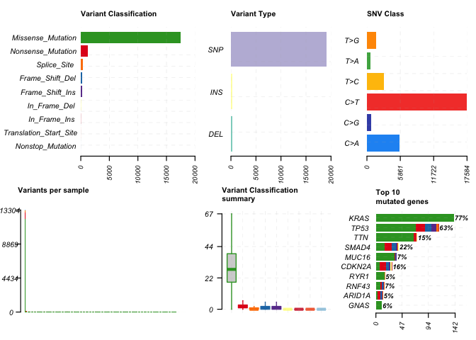

```r
plotmafSummary(vars)
```

## Drawing oncoplots

A very useful summary representation of this data can be obtained via so-called *oncoplots*, also known as *waterfall plots*.

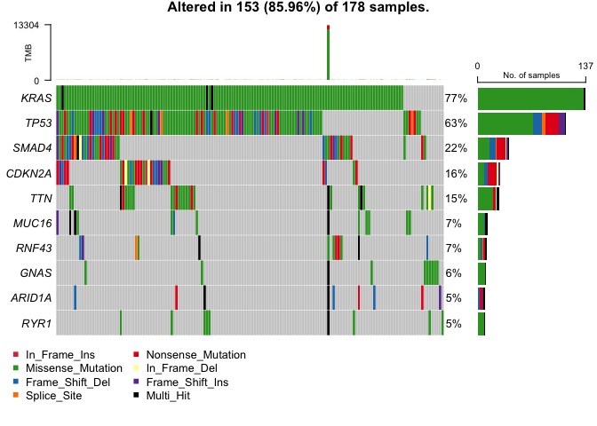

```r
oncoplot(maf = vars, top = 10)
```

You might need to run the **oncoplot()** command in the R Console and then zoom the display to see the full plot (as it is rather large and may not appear initially in your Rmarkdown document before Knitting. Another option is to send your plot to a PNG or PDF plot device directly, for example:

```r
# Oncoplot for our top 10 most frequently mutated genes
pdf("oncoplot_panc.pdf")
oncoplot(maf = vars, top = 10, fontSize = 12)
dev.off()
```

Oncoplots display the *“mutational landscape”* of patients accross specific genes of interest. By default, and in the plot above, the top 10 mutated genes in the cohort are used. Each column is a patient and each row is a gene of interest (sorted by the mutation rate of that gene in the cohort). Each colored cell indicates that the patient has a mutation in that gene and it is color-coded by the type of mutation (depicted in the legend on the bottom left of the plot).

For example, in the oncoplot above KRAS is depicted as the most frequently mutated gene in the cohort (77% of the time), following by TP53 (63%). KRAS misssense mutations predominate. Many patients have both KRAS and TP53 mutations. A small subset of patients have either TP53 or GNAS mutations but no KRAS mutation. These observations could lead to questions such as – What role does mutated KRAS play in these patients? What is distinct about TP53 and GNAS mutations in the absence of KRAS mutations? Could these top 10 genes be affecting certain pathways that may lead to these patients acquiring this disease?

> **NOTE**: The **oncoplot()** function is a wrapper around ComplexHeatmap’s `OncoPrint()` function and there are lots and lots of possible customization options as usual with R graphics.

> **NOTE**: Variants annotated as Multi_Hit are those genes which are mutated more than once in the same sample.

## Oncostrip

We can visualize any subset set of genes using the **oncostrip()** function, which draws mutations in each sample similar to the graphic on the NCI-GDC web portal. Note that **oncostrip()** can be used to draw any number of genes using the input `top` or `genes` arguments

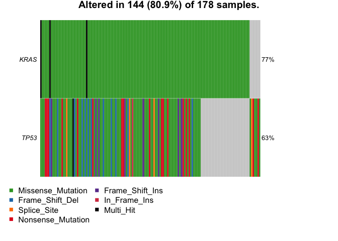

```r
oncostrip(maf=vars, genes=c("KRAS", "TP53"))
```

Another plot focusing on KRAS in our particular dataset.

```
##    HGNC refseq.ID protein.ID aa.length
## 1: KRAS NM_004985  NP_004976       188
## 2: KRAS NM_033360  NP_203524       189
```

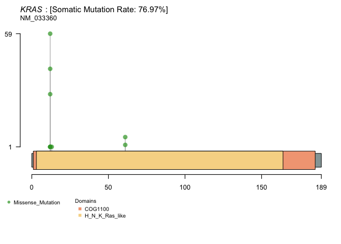

```r
lollipopPlot(vars, gene='KRAS')
```

> **Q11**. Adapt the code above to produce a lollipop plot for p53 (i.e. the ‘TP53’ gene)?

Your p53 plot should look like this:

```
##    HGNC    refseq.ID   protein.ID aa.length
## 1: TP53    NM_000546    NP_000537       393
## 2: TP53 NM_001126112 NP_001119584       393
## 3: TP53 NM_001126113 NP_001119585       346
## 4: TP53 NM_001126114 NP_001119586       341
## 5: TP53 NM_001126115 NP_001119587       261
## 6: TP53 NM_001126116 NP_001119588       209
## 7: TP53 NM_001126117 NP_001119589       214
## 8: TP53 NM_001126118 NP_001119590       354
```

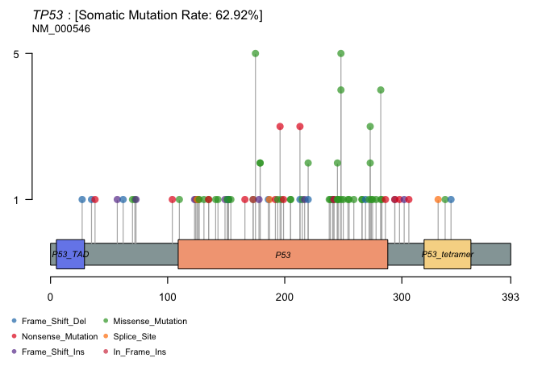

# Summary

Additional functionality is available for each of the `GenomicDataCommons`, `TCGAbiolinks` and `maftools` packages not to mention the 100’s of other bioinformatics R packages that can now work with this type of data in both exploratory and targeted analysis modes.

The purpose of this hands-on session was to highlight how one can leverage three such packages to quickly gain insight into rapidly expanding public cancer genomics data-sets. Hopefully this will inspire your further exploration of these and other bioinformatics R packages.